# House Price Prediction

Carlos Silva

2020-02-24

# 1 Introduction

## 1.1 Description

Ask a home buyer to describe their dream house, and they probably won’t begin with the height of the basement ceiling or the proximity to an east-west railroad. But this playground competition’s dataset proves that much more influences price negotiations than the number of bedrooms or a white-picket fence.

## 1.2 Objective

With 79 explanatory variables describing (almost) every aspect of residential homes in Ames and Iowa. the goal is to predict the sales price for each house. For each Id in the test set, the model will predict the value of the SalePrice variable.

# 2 Set up

## 2.1 Load Packages

```r
require(tidyverse)
require(skimr)
require(caret)
require(caretEnsemble)
require(xgboost)
require(kernlab)
require(Matrix)
require(recipes)
```

## 2.2 Load Datasets

```r
db1 <- read.csv('train.csv')
db2 <- read.csv('test.csv')
db2$SalePrice <- as.integer(NA)
hp <- rbind(db1, db2)
remove(db1); remove(db2)
```

# 3 Overview of the Data

```r
skim(hp)
```

Data summary

| Name | hp |
| --- | --- |
| Number of rows | 2919 |
| Number of columns | 81 |
| _______________________ |  |
| Column type frequency: |  |
| factor | 43 |
| numeric | 38 |
| ________________________ |  |
| Group variables | None |

**Variable type: factor**

| skim_variable | n_missing | complete_rate | ordered | n_unique | top_counts |
| --- | --- | --- | --- | --- | --- |
| MSZoning | 4 | 1.00 | FALSE | 5 | RL: 2265, RM: 460, FV: 139, RH: 26 |
| Street | 0 | 1.00 | FALSE | 2 | Pav: 2907, Grv: 12 |
| Alley | 2721 | 0.07 | FALSE | 2 | Grv: 120, Pav: 78 |
| LotShape | 0 | 1.00 | FALSE | 4 | Reg: 1859, IR1: 968, IR2: 76, IR3: 16 |
| LandContour | 0 | 1.00 | FALSE | 4 | Lvl: 2622, HLS: 120, Bnk: 117, Low: 60 |
| Utilities | 2 | 1.00 | FALSE | 2 | All: 2916, NoS: 1 |
| LotConfig | 0 | 1.00 | FALSE | 5 | Ins: 2133, Cor: 511, Cul: 176, FR2: 85 |
| LandSlope | 0 | 1.00 | FALSE | 3 | Gtl: 2778, Mod: 125, Sev: 16 |
| Neighborhood | 0 | 1.00 | FALSE | 25 | NAm: 443, Col: 267, Old: 239, Edw: 194 |
| Condition1 | 0 | 1.00 | FALSE | 9 | Nor: 2511, Fee: 164, Art: 92, RRA: 50 |
| Condition2 | 0 | 1.00 | FALSE | 8 | Nor: 2889, Fee: 13, Art: 5, Pos: 4 |
| BldgType | 0 | 1.00 | FALSE | 5 | 1Fa: 2425, Twn: 227, Dup: 109, Twn: 96 |
| HouseStyle | 0 | 1.00 | FALSE | 8 | 1St: 1471, 2St: 872, 1.5: 314, SLv: 128 |
| RoofStyle | 0 | 1.00 | FALSE | 6 | Gab: 2310, Hip: 551, Gam: 22, Fla: 20 |
| RoofMatl | 0 | 1.00 | FALSE | 8 | Com: 2876, Tar: 23, WdS: 9, WdS: 7 |
| Exterior1st | 1 | 1.00 | FALSE | 15 | Vin: 1025, Met: 450, HdB: 442, Wd : 411 |
| Exterior2nd | 1 | 1.00 | FALSE | 16 | Vin: 1014, Met: 447, HdB: 406, Wd : 391 |
| MasVnrType | 24 | 0.99 | FALSE | 4 | Non: 1742, Brk: 879, Sto: 249, Brk: 25 |
| ExterQual | 0 | 1.00 | FALSE | 4 | TA: 1798, Gd: 979, Ex: 107, Fa: 35 |
| ExterCond | 0 | 1.00 | FALSE | 5 | TA: 2538, Gd: 299, Fa: 67, Ex: 12 |
| Foundation | 0 | 1.00 | FALSE | 6 | PCo: 1308, CBl: 1235, Brk: 311, Sla: 49 |
| BsmtQual | 81 | 0.97 | FALSE | 4 | TA: 1283, Gd: 1209, Ex: 258, Fa: 88 |
| BsmtCond | 82 | 0.97 | FALSE | 4 | TA: 2606, Gd: 122, Fa: 104, Po: 5 |
| BsmtExposure | 82 | 0.97 | FALSE | 4 | No: 1904, Av: 418, Gd: 276, Mn: 239 |
| BsmtFinType1 | 79 | 0.97 | FALSE | 6 | Unf: 851, GLQ: 849, ALQ: 429, Rec: 288 |
| BsmtFinType2 | 80 | 0.97 | FALSE | 6 | Unf: 2493, Rec: 105, LwQ: 87, BLQ: 68 |
| Heating | 0 | 1.00 | FALSE | 6 | Gas: 2874, Gas: 27, Gra: 9, Wal: 6 |
| HeatingQC | 0 | 1.00 | FALSE | 5 | Ex: 1493, TA: 857, Gd: 474, Fa: 92 |
| CentralAir | 0 | 1.00 | FALSE | 2 | Y: 2723, N: 196 |
| Electrical | 1 | 1.00 | FALSE | 5 | SBr: 2671, Fus: 188, Fus: 50, Fus: 8 |
| KitchenQual | 1 | 1.00 | FALSE | 4 | TA: 1492, Gd: 1151, Ex: 205, Fa: 70 |
| Functional | 2 | 1.00 | FALSE | 7 | Typ: 2717, Min: 70, Min: 65, Mod: 35 |
| FireplaceQu | 1420 | 0.51 | FALSE | 5 | Gd: 744, TA: 592, Fa: 74, Po: 46 |
| GarageType | 157 | 0.95 | FALSE | 6 | Att: 1723, Det: 779, Bui: 186, Bas: 36 |
| GarageFinish | 159 | 0.95 | FALSE | 3 | Unf: 1230, RFn: 811, Fin: 719 |
| GarageQual | 159 | 0.95 | FALSE | 5 | TA: 2604, Fa: 124, Gd: 24, Po: 5 |
| GarageCond | 159 | 0.95 | FALSE | 5 | TA: 2654, Fa: 74, Gd: 15, Po: 14 |
| PavedDrive | 0 | 1.00 | FALSE | 3 | Y: 2641, N: 216, P: 62 |
| PoolQC | 2909 | 0.00 | FALSE | 3 | Ex: 4, Gd: 4, Fa: 2 |
| Fence | 2348 | 0.20 | FALSE | 4 | MnP: 329, GdP: 118, GdW: 112, MnW: 12 |
| MiscFeature | 2814 | 0.04 | FALSE | 4 | She: 95, Gar: 5, Oth: 4, Ten: 1 |
| SaleType | 1 | 1.00 | FALSE | 9 | WD: 2525, New: 239, COD: 87, Con: 26 |
| SaleCondition | 0 | 1.00 | FALSE | 6 | Nor: 2402, Par: 245, Abn: 190, Fam: 46 |

**Variable type: numeric**

| skim_variable | n_missing | complete_rate | mean | sd | p0 | p25 | p50 | p75 | p100 | hist |
| --- | --- | --- | --- | --- | --- | --- | --- | --- | --- | --- |
| Id | 0 | 1.00 | 1460.00 | 842.79 | 1 | 730.5 | 1460.0 | 2189.5 | 2919 | ▇▇▇▇▇ |
| MSSubClass | 0 | 1.00 | 57.14 | 42.52 | 20 | 20.0 | 50.0 | 70.0 | 190 | ▇▅▂▁▁ |
| LotFrontage | 486 | 0.83 | 69.31 | 23.34 | 21 | 59.0 | 68.0 | 80.0 | 313 | ▇▃▁▁▁ |
| LotArea | 0 | 1.00 | 10168.11 | 7887.00 | 1300 | 7478.0 | 9453.0 | 11570.0 | 215245 | ▇▁▁▁▁ |
| OverallQual | 0 | 1.00 | 6.09 | 1.41 | 1 | 5.0 | 6.0 | 7.0 | 10 | ▁▂▇▅▁ |
| OverallCond | 0 | 1.00 | 5.56 | 1.11 | 1 | 5.0 | 5.0 | 6.0 | 9 | ▁▁▇▅▁ |
| YearBuilt | 0 | 1.00 | 1971.31 | 30.29 | 1872 | 1953.5 | 1973.0 | 2001.0 | 2010 | ▁▂▃▆▇ |
| YearRemodAdd | 0 | 1.00 | 1984.26 | 20.89 | 1950 | 1965.0 | 1993.0 | 2004.0 | 2010 | ▅▂▂▃▇ |
| MasVnrArea | 23 | 0.99 | 102.20 | 179.33 | 0 | 0.0 | 0.0 | 164.0 | 1600 | ▇▁▁▁▁ |
| BsmtFinSF1 | 1 | 1.00 | 441.42 | 455.61 | 0 | 0.0 | 368.5 | 733.0 | 5644 | ▇▁▁▁▁ |
| BsmtFinSF2 | 1 | 1.00 | 49.58 | 169.21 | 0 | 0.0 | 0.0 | 0.0 | 1526 | ▇▁▁▁▁ |
| BsmtUnfSF | 1 | 1.00 | 560.77 | 439.54 | 0 | 220.0 | 467.0 | 805.5 | 2336 | ▇▅▂▁▁ |
| TotalBsmtSF | 1 | 1.00 | 1051.78 | 440.77 | 0 | 793.0 | 989.5 | 1302.0 | 6110 | ▇▃▁▁▁ |
| X1stFlrSF | 0 | 1.00 | 1159.58 | 392.36 | 334 | 876.0 | 1082.0 | 1387.5 | 5095 | ▇▃▁▁▁ |
| X2ndFlrSF | 0 | 1.00 | 336.48 | 428.70 | 0 | 0.0 | 0.0 | 704.0 | 2065 | ▇▃▂▁▁ |
| LowQualFinSF | 0 | 1.00 | 4.69 | 46.40 | 0 | 0.0 | 0.0 | 0.0 | 1064 | ▇▁▁▁▁ |
| GrLivArea | 0 | 1.00 | 1500.76 | 506.05 | 334 | 1126.0 | 1444.0 | 1743.5 | 5642 | ▇▇▁▁▁ |
| BsmtFullBath | 2 | 1.00 | 0.43 | 0.52 | 0 | 0.0 | 0.0 | 1.0 | 3 | ▇▆▁▁▁ |
| BsmtHalfBath | 2 | 1.00 | 0.06 | 0.25 | 0 | 0.0 | 0.0 | 0.0 | 2 | ▇▁▁▁▁ |
| FullBath | 0 | 1.00 | 1.57 | 0.55 | 0 | 1.0 | 2.0 | 2.0 | 4 | ▁▇▇▁▁ |
| HalfBath | 0 | 1.00 | 0.38 | 0.50 | 0 | 0.0 | 0.0 | 1.0 | 2 | ▇▁▅▁▁ |
| BedroomAbvGr | 0 | 1.00 | 2.86 | 0.82 | 0 | 2.0 | 3.0 | 3.0 | 8 | ▁▇▂▁▁ |
| KitchenAbvGr | 0 | 1.00 | 1.04 | 0.21 | 0 | 1.0 | 1.0 | 1.0 | 3 | ▁▇▁▁▁ |
| TotRmsAbvGrd | 0 | 1.00 | 6.45 | 1.57 | 2 | 5.0 | 6.0 | 7.0 | 15 | ▁▇▂▁▁ |
| Fireplaces | 0 | 1.00 | 0.60 | 0.65 | 0 | 0.0 | 1.0 | 1.0 | 4 | ▇▇▁▁▁ |
| GarageYrBlt | 159 | 0.95 | 1978.11 | 25.57 | 1895 | 1960.0 | 1979.0 | 2002.0 | 2207 | ▂▇▁▁▁ |
| GarageCars | 1 | 1.00 | 1.77 | 0.76 | 0 | 1.0 | 2.0 | 2.0 | 5 | ▅▇▂▁▁ |
| GarageArea | 1 | 1.00 | 472.87 | 215.39 | 0 | 320.0 | 480.0 | 576.0 | 1488 | ▃▇▃▁▁ |
| WoodDeckSF | 0 | 1.00 | 93.71 | 126.53 | 0 | 0.0 | 0.0 | 168.0 | 1424 | ▇▁▁▁▁ |
| OpenPorchSF | 0 | 1.00 | 47.49 | 67.58 | 0 | 0.0 | 26.0 | 70.0 | 742 | ▇▁▁▁▁ |
| EnclosedPorch | 0 | 1.00 | 23.10 | 64.24 | 0 | 0.0 | 0.0 | 0.0 | 1012 | ▇▁▁▁▁ |
| X3SsnPorch | 0 | 1.00 | 2.60 | 25.19 | 0 | 0.0 | 0.0 | 0.0 | 508 | ▇▁▁▁▁ |
| ScreenPorch | 0 | 1.00 | 16.06 | 56.18 | 0 | 0.0 | 0.0 | 0.0 | 576 | ▇▁▁▁▁ |
| PoolArea | 0 | 1.00 | 2.25 | 35.66 | 0 | 0.0 | 0.0 | 0.0 | 800 | ▇▁▁▁▁ |
| MiscVal | 0 | 1.00 | 50.83 | 567.40 | 0 | 0.0 | 0.0 | 0.0 | 17000 | ▇▁▁▁▁ |
| MoSold | 0 | 1.00 | 6.21 | 2.71 | 1 | 4.0 | 6.0 | 8.0 | 12 | ▅▆▇▃▃ |
| YrSold | 0 | 1.00 | 2007.79 | 1.31 | 2006 | 2007.0 | 2008.0 | 2009.0 | 2010 | ▇▇▇▇▃ |
| SalePrice | 1459 | 0.50 | 180921.20 | 79442.50 | 34900 | 129975.0 | 163000.0 | 214000.0 | 755000 | ▇▅▁▁▁ |

# 4 Data Preparation

## 4.1 Fix variable name starts with number

```r
names(hp)[44:45] <- c("FirstFLSF","SecFLSF")
names(hp)[70] <- c("ThreeSnPorch")
```

## 4.2 Fix typos in factorial levels

```r
count(hp, RoofMatl)
```

```
## # A tibble: 8 x 2
##   RoofMatl     n
##   <fct>    <int>
## 1 ClyTile      1
## 2 CompShg   2876
## 3 Membran      1
## 4 Metal        1
## 5 Roll         1
## 6 Tar&Grv     23
## 7 WdShake      9
## 8 WdShngl      7
```

```r
hp <- hp %>%
        mutate(RoofMatl = fct_collapse(RoofMatl, "TarGrv" = "Tar&Grv"))
```

```r
count(hp, Exterior1st)
```

```
## # A tibble: 16 x 2
##    Exterior1st     n
##    <fct>       <int>
##  1 AsbShng        44
##  2 AsphShn         2
##  3 BrkComm         6
##  4 BrkFace        87
##  5 CBlock          2
##  6 CemntBd       126
##  7 HdBoard       442
##  8 ImStucc         1
##  9 MetalSd       450
## 10 Plywood       221
## 11 Stone           2
## 12 Stucco         43
## 13 VinylSd      1025
## 14 Wd Sdng       411
## 15 WdShing        56
## 16 <NA>            1
```

```r
hp <- hp %>%
        mutate(Exterior1st = fct_collapse(Exterior1st, "WdSdng" = "Wd Sdng"))
```

```r
count(hp, Exterior2nd)
```

```
## # A tibble: 17 x 2
##    Exterior2nd     n
##    <fct>       <int>
##  1 AsbShng        38
##  2 AsphShn         4
##  3 Brk Cmn        22
##  4 BrkFace        47
##  5 CBlock          3
##  6 CmentBd       126
##  7 HdBoard       406
##  8 ImStucc        15
##  9 MetalSd       447
## 10 Other           1
## 11 Plywood       270
## 12 Stone           6
## 13 Stucco         47
## 14 VinylSd      1014
## 15 Wd Sdng       391
## 16 Wd Shng        81
## 17 <NA>            1
```

```r
hp <- hp %>%
        mutate(Exterior2nd = fct_collapse(Exterior2nd, "BrkComm" = "Brk Cmn", "WdSdng" = "Wd Sdng", "WdShng" = "Wd Shng"))
```

## 4.3 Remove Outliers

we can identify two outlier points (Id = 524, 1299) in this plot SalePrice against GrLivArea, the other outlier points (Id = -463,-633,-1325,-31,-971) were identified after visualize the residuals plot of the model fitted.

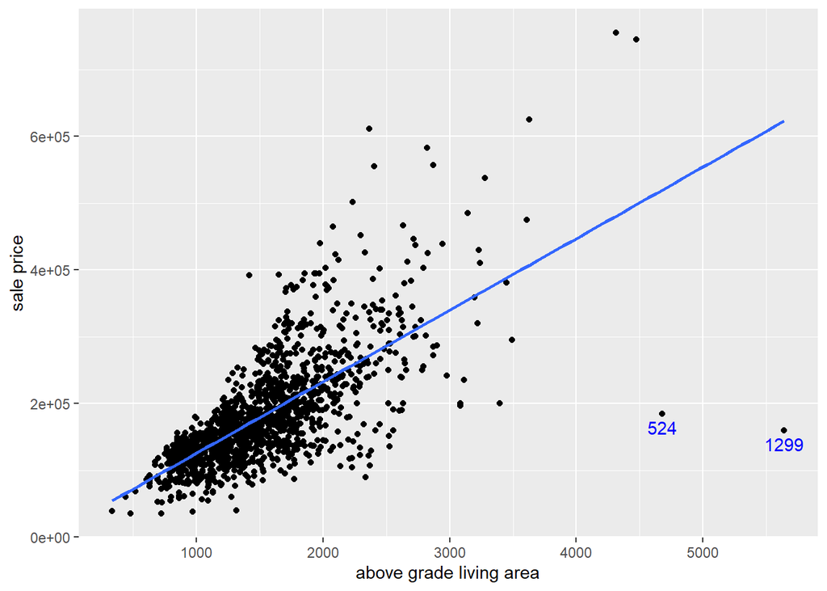

```r
ggplot(hp, aes(x=GrLivArea, y=SalePrice)) +
        geom_point() +
        geom_smooth(method=lm, se=FALSE) +
        geom_text(data = hp[hp$GrLivArea>4500,], mapping=aes(label=Id), vjust=1.5, col = "blue") +
        xlab("above grade living area") +
        ylab("sale price")
```

```r
outlier <- c(524, 1299, 463, 633, 1325, 31, 971)
hp<- hp[!hp$Id %in% outlier, ]
```

# 5 Feature engineering

Transforming and combining variables to data set.

```r
hp <- hp  %>%
        mutate(withBsmt = as.numeric(TotalBsmtSF!=0),
               with2ndFloor= as.numeric(SecFLSF>0),
               withPool = as.numeric(PoolArea!=0),
               withPorch = as.numeric((OpenPorchSF+EnclosedPorch+ThreeSnPorch+ScreenPorch)!=0),
               hasRemod = as.numeric(YearRemodAdd != YearBuilt),
               withFireplace = as.numeric(Fireplaces >0),
               isNew = as.numeric(YrSold == YearBuilt),
               totalSF = GrLivArea + TotalBsmtSF,
               totalBath = FullBath + 0.5*HalfBath + 0.5*BsmtHalfBath + BsmtFullBath,
               age = YrSold - YearRemodAdd,
               yearsRemodeled = ifelse(YearRemodAdd == YearBuilt, YrSold < YearRemodAdd, 0),
               YrSold = factor(YrSold),
               MoSold = factor(MoSold),
               MSSubClass = factor(MSSubClass),
               OverallQual = factor(OverallQual),
               OverallCond = factor(OverallCond),
               totalPorchSF = OpenPorchSF + EnclosedPorch + ThreeSnPorch + ScreenPorch,
               withbsmtBath = as.numeric(BsmtHalfBath + BsmtFullBath!=0),
               isBsmtUnf = as.numeric(TotalBsmtSF == BsmtUnfSF)
        )
```

# 6 Data preprocessing

Recipe package was used to do preprocessing

## 6.1 Split the data

```r
hp_train <- hp[!is.na(hp$SalePrice),]
hp_test <- hp[is.na(hp$SalePrice),]
set.seed(2123)
```

## 6.2 Define the recipe

```r
model_recipe <- recipe(SalePrice ~ ., data = hp_train) %>%
        update_role(Id, new_role = "id var") %>%
        step_knnimpute(all_predictors()) %>%
        step_dummy(all_predictors(), -all_numeric()) %>%
        step_BoxCox(all_predictors()) %>%
        step_center(all_predictors())  %>%
        step_scale(all_predictors()) %>%
        step_zv(all_predictors()) %>%
        step_corr(all_predictors(), threshold = .9) %>%
        step_log(all_outcomes()) %>%
        check_missing(all_predictors())

model_recipe
```

```
## Data Recipe
##
## Inputs:
##
##       role #variables
##     id var          1
##    outcome          1
##  predictor         93
##
## Operations:
##
## 5-nearest neighbor imputation for all_predictors
## Dummy variables from all_predictors, -, all_numeric()
## Box-Cox transformation on all_predictors
## Centering for all_predictors
## Scaling for all_predictors
## Zero variance filter on all_predictors
## Correlation filter on all_predictors
## Log transformation on all_outcomes
## Check missing values for all_predictors
```

## 6.3 Preparing and Bake the recipe

```r
prepped_recipe <- prep(model_recipe, training = hp_train)
prepped_recipe
```

```
## Data Recipe
##
## Inputs:
##
##       role #variables
##     id var          1
##    outcome          1
##  predictor         93
##
## Training data contained 1453 data points and 1453 incomplete rows.
##
## Operations:
##
## 5-nearest neighbor imputation for MSZoning, LotFrontage, LotArea, Street, ... [trained]
## Dummy variables from MSSubClass, MSZoning, Street, Alley, ... [trained]
## Box-Cox transformation on LotFrontage, LotArea, FirstFLSF, ... [trained]
## Centering for LotFrontage, LotArea, YearBuilt, ... [trained]
## Scaling for LotFrontage, LotArea, YearBuilt, ... [trained]
## Zero variance filter removed yearsRemodeled, MSSubClass_X150 [trained]
## Correlation filter removed withPool, withFireplace, ... [trained]
## Log transformation on SalePrice [trained]
## Check missing values for LotFrontage, LotArea, YearBuilt, ... [trained]
```

```r
train <- bake(prepped_recipe, new_data = hp_train)
test <- bake(prepped_recipe, new_data = hp_test)
```

## 6.4 Check the data

```r
anyNA(subset(train, select=-SalePrice))
```

```
## [1] FALSE
```

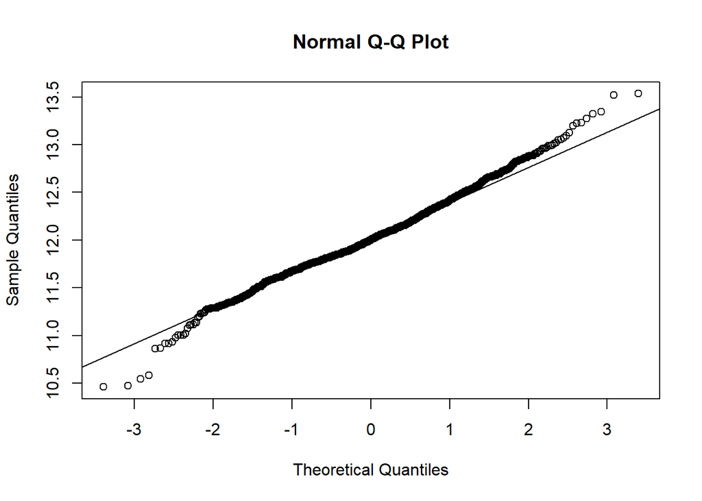

```r
qqnorm(train$SalePrice)
qqline(train$SalePrice)
```

# 7 Modeling

Use xgboost model to determin the best nRound value (number of iterations)

```r
params<-list(
        max_depth = 4, # default=6
        eta = 0.02, # it lies between 0.01 - 0.3
        gamma = 0, # default=0
        colsample_bytree = 0.65, # Typically, its values lie between (0.5,0.9)
        subsample = 0.6, # Typically, its values lie between (0.5-0.8)
        min_child_weight = 3 # default=1
)
```

## 7.1 Preparing matrix

```r
dtrain <- xgb.DMatrix(data = sparse.model.matrix(SalePrice~ .-Id, train), label= train$SalePrice)
```

## 7.2 Calculate the best nround for this model

```r
set.seed(2123)
xgbcv <- xgb.cv( params = params, data = dtrain, label = train$SalePrice, nrounds = 2000, nfold = 10, showsd = F, stratified = T, print_every_n = 250, early_stopping_rounds = 50, maximize = F)
```

[output not shown]

```r
niter <- xgbcv$best_iteration
```

## 7.3 Check the most important features

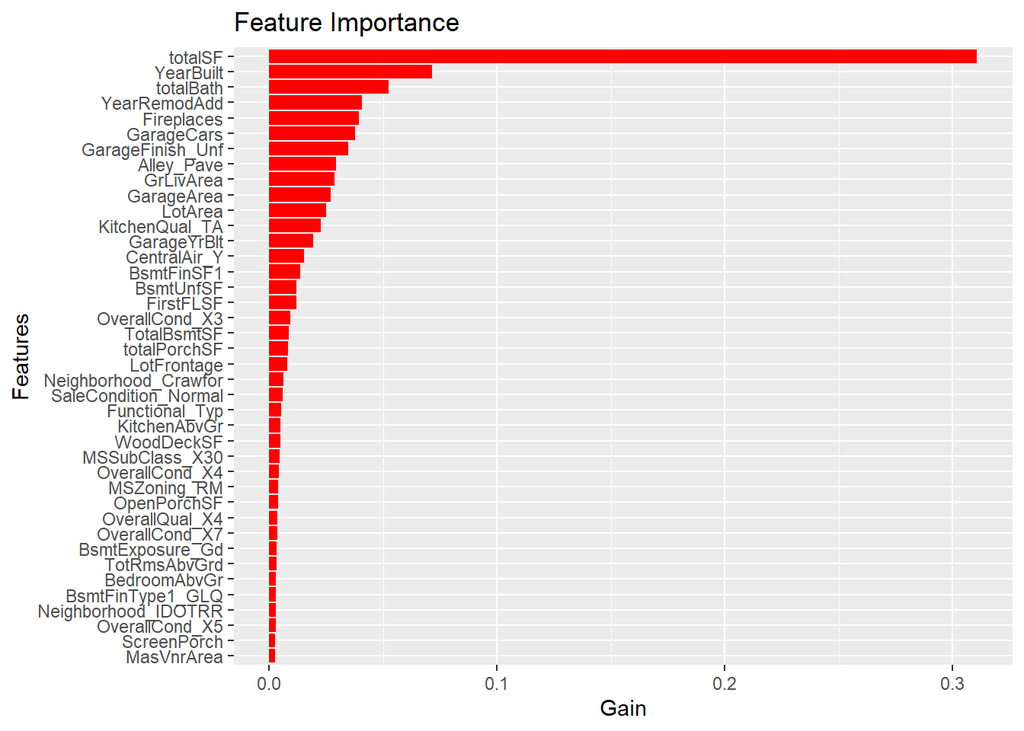

```r
xgb1 <- xgb.train(data = dtrain, params=params, nrounds = niter)
mat <- xgb.importance(feature_names = xgb1$feature_names, model = xgb1)
ggplot(mat[1:40,])+
        geom_bar(aes(x=reorder(Feature, Gain), y=Gain), stat='identity', fill='red')+
        xlab(label = "Features")+
        coord_flip() +
        ggtitle("Feature Importance")
```

## 7.4 Do caret ensemble model

To make ensemble model were choosed a boosted tree model (xgboost), a regularized linear model (lasso), and a non-linear kernel SVM (svmRadial).

```r
set.seed(2123)
trControl <- trainControl(
        method='cv',
        savePredictions="final",
        index = createFolds(train$SalePrice,k = 10, returnTrain = TRUE),
        allowParallel =TRUE,
        verboseIter = TRUE
)

xgbGrid <- expand.grid(nrounds = niter, max_depth = c(3,4,5), eta = 0.02, gamma = 0, colsample_bytree = c(0.65),  subsample = c(0.6), min_child_weight = c(3,4,5))
glmGrid <- expand.grid(alpha = 1, lambda = seq(0.00001,0.01,by = 0.0001))
svmGrid <- expand.grid(sigma= 2^seq(-11, -16, -0.5), C= 2^seq(4,9,1))

model <<- caretList(
        x = subset(train, select=-c(Id, SalePrice)),
        y = train$SalePrice,
        trControl=trControl,
        metric="RMSE",
        tuneList=list(
                xgb2 = caretModelSpec(method="xgbTree",  tuneGrid = xgbGrid),
                glm=caretModelSpec(method="glmnet", tuneGrid = glmGrid),
                svm = caretModelSpec(method="svmRadial", tuneGrid = svmGrid, preProcess=c("nzv", "pca"))
        )
)
```

```
## Fitting nrounds = 1814, max_depth = 4, eta = 0.02, gamma = 0, colsample_bytree = 0.65, min_child_weight = 3, subsample = 0.6 on full training set
```

# 8 Model performance

## 8.1 Check the tuning result, performance of each model and correlation between models

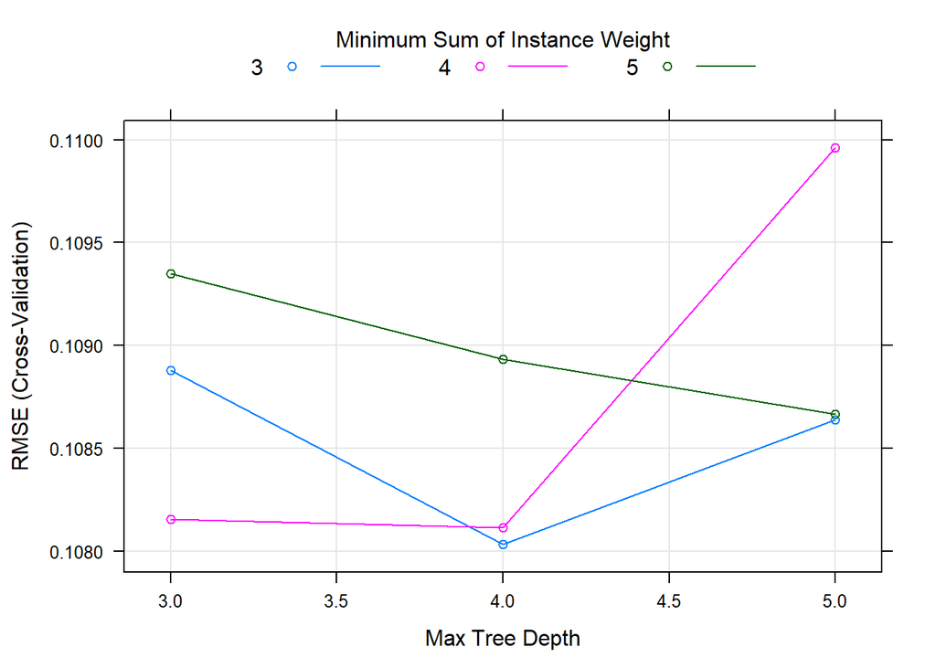

```r
plot(model$xgb2)
```

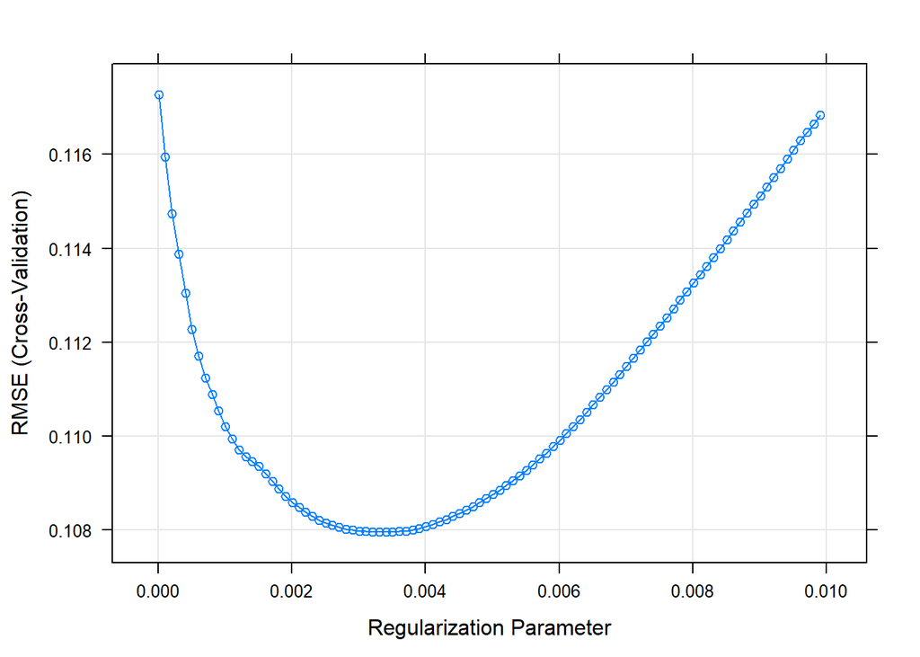

```r
plot(model$glm)
```

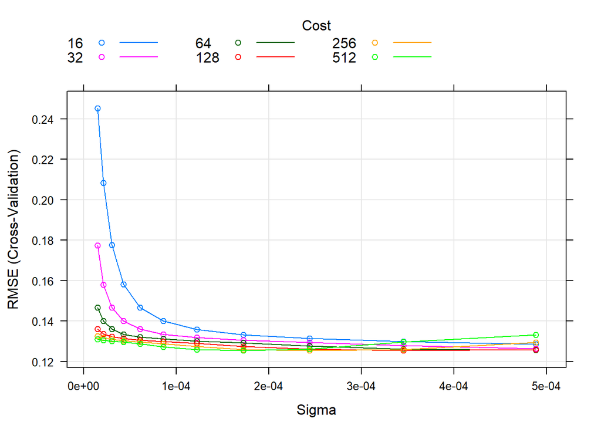

```r
plot(model$svm)
```

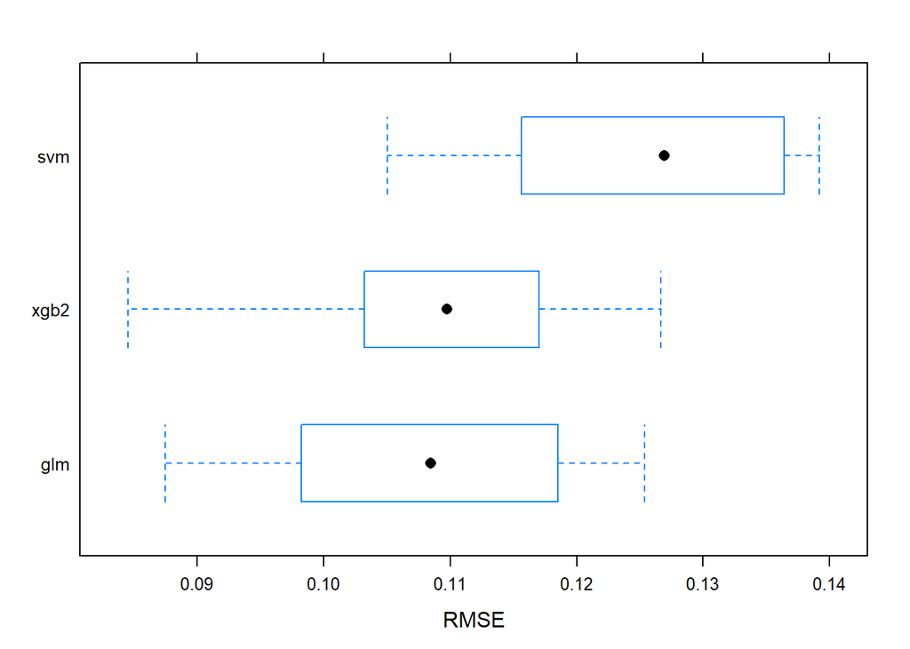

```r
bwplot(resamples(model),metric="RMSE")
```

```r
modelCor(resamples(model))
```

```
##           xgb2       glm       svm
## xgb2 1.0000000 0.8581664 0.7396069
## glm  0.8581664 1.0000000 0.8290225
## svm  0.7396069 0.8290225 1.0000000
```

## 8.2 Final stacking on the three models

```r
model_Ensemble <- caretEnsemble(
        model,
        metric="RMSE",
        trControl=trainControl(number=10, method = "repeatedcv", repeats=3)
)
summary(model_Ensemble)
```

```
## The following models were ensembled: xgb2, glm, svm
## They were weighted:
## -0.2618 0.4884 0.4991 0.0342
## The resulting RMSE is: 0.1043
## The fit for each individual model on the RMSE is:
##  method      RMSE     RMSESD
##    xgb2 0.1080316 0.01240736
##     glm 0.1079561 0.01180730
##     svm 0.1253965 0.01167731
```

## 8.3 Check the residuals

Visualize which data points gave highest prediction errors in the training set. The outliers were spotted at this step

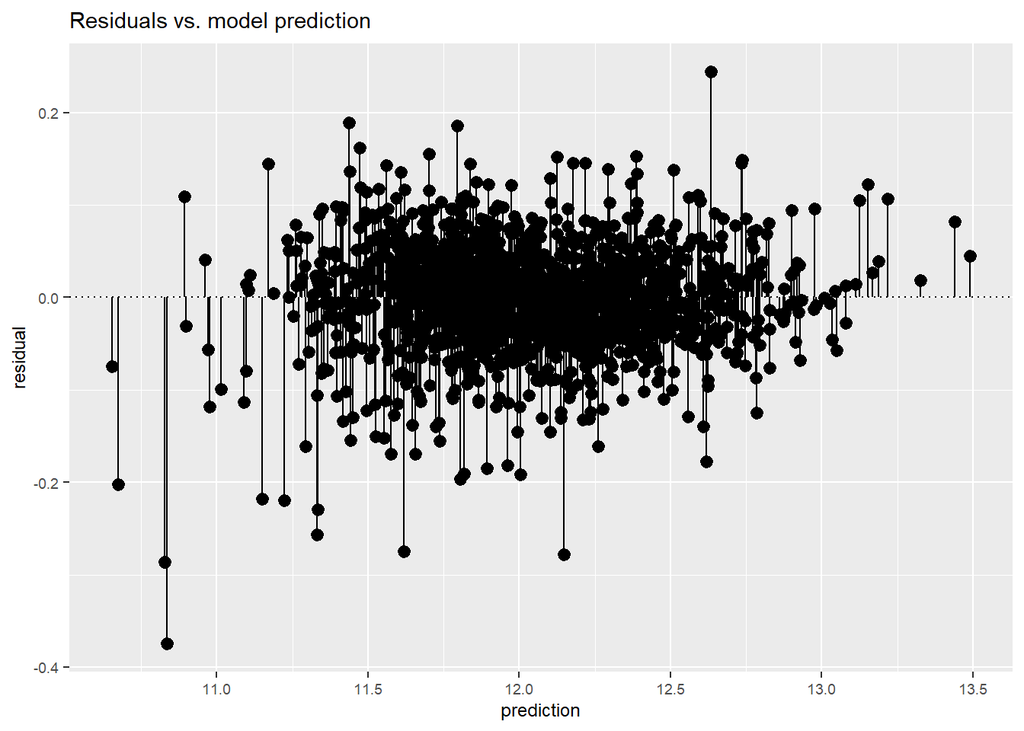

```r
pred.train <- predict(model_Ensemble, newdata=subset(train, select=-c(Id, SalePrice)))
hp.plot <- hp %>%
        filter(!is.na(SalePrice))
hp.plot$pred <- pred.train
hp.plot <- hp.plot %>%
        mutate(residual = log(SalePrice)-pred)



ggplot(hp.plot, aes(x = pred, y = residual)) +
        geom_pointrange(aes(ymin = 0, ymax = residual)) +
        geom_hline(yintercept = 0, linetype = 3) +
        geom_text(data = hp.plot[abs(hp.plot$residual) > 0.4,], aes(label = Id), vjust=1.5, col = "red") +
        ggtitle("Residuals vs. model prediction") +
        xlab("prediction") +
        ylab("residual") +
        theme(text = element_text(size=9))
```

## 8.4 Final prediction

```r
finalPredictions <- predict(model_Ensemble, newdata=subset(test, select=-c(Id, SalePrice)))
finalPredictions <- data.frame('Id'= hp_test$Id, 'SalePrice'=exp(finalPredictions))
write.csv(finalPredictions, file="finalpredictions.csv", row.names = F)
```